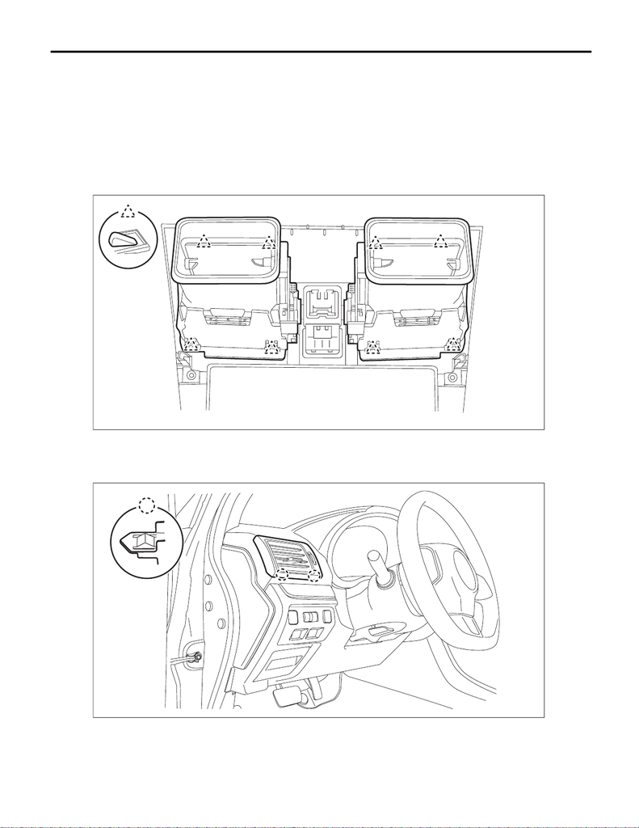

AC-91

Air Vent Grille

HVAC SYSTEM (HEATER, VENTILATOR AND A/C)

28.Air Vent Grille

A: REMOVAL

1. CENTER GRILLE ASSEMBLY

1) Disconnect the ground cable from battery. <Ref. to NT-5, BATTERY, NOTE, Note.>

NOTE:

For models other than STI model, disconnect the ground terminal from battery sensor.

2) Remove the panel center assembly. <Ref. to EI-66, REMOVAL, Center Console.>

3) Release the claws, and then remove the grille assembly - CTR ventilation.

2. SIDE GRILLE ASSEMBLY

Release the claws, and then remove the grille assembly - ventilation.

•LH side

AC-03571

AC-03572

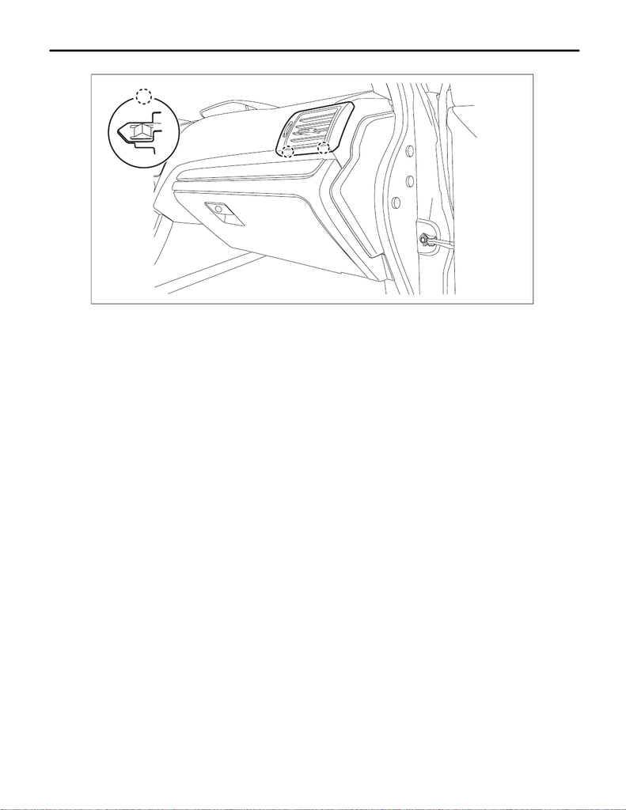

AC-92

Air Vent Grille

HVAC SYSTEM (HEATER, VENTILATOR AND A/C)

• RH side

B: INSTALLATION

1. CENTER GRILLE ASSEMBLY

CAUTION:

After installing the panel center assembly or grille assembly - ventilation, check that the air vent grille

is inserted correctly into the air vent duct.

1) Install the grille assembly - CTR ventilation.

2) Install the panel center assembly.

3) Connect the battery ground terminal. <Ref. to NT-5, BATTERY, NOTE, Note.>

NOTE:

For models other than STI model, connect the ground terminal to battery sensor.

2. SIDE GRILLE ASSEMBLY

CAUTION:

After installing the panel center assembly or grille assembly - ventilation, check that the air vent grille

is inserted correctly into the air vent duct.

Install the grille assembly - ventilation.

C: INSPECTION

2) Check that the adjustment can be maintained in each position. Replace the grille assembly - ventilation if

faulty.

AC-03573